# 16S-workshop

Hardik I Parikh

4/18/2018

This markdown outlines instructions for visualization and analysis of OTU-clustered amplicon sequencing data, primarily using the *phyloseq* package.

### Prerequisites

- R basics
- Data manipulation with dplyr and `%>%`
- Data visualization with ggplot2

#### R packages

*CRAN packages*

- [tidyverse (readr, dplyr, ggplot2)](https://www.tidyverse.org/packages/)
- [magrittr](https://cran.r-project.org/web/packages/magrittr/vignettes/magrittr.html)
- [reshape2](https://cran.r-project.org/web/packages/reshape2/reshape2.pdf)
- [vegan](https://cran.r-project.org/web/packages/vegan/vignettes/intro-vegan.pdf)
- [ape](https://cran.r-project.org/web/packages/ape/ape.pdf)
- [ggpubr](http://www.sthda.com/english/rpkgs/ggpubr/)
- [RColorBrewer](https://cran.r-project.org/web/packages/RColorBrewer/RColorBrewer.pdf)

*Bioconductor packages*

- [phyloseq](https://joey711.github.io/phyloseq/)
- [DESeq2](http://bioconductor.org/packages/devel/bioc/vignettes/DESeq2/inst/doc/DESeq2.html)

#### Required Data Files

We will use the output files generated during the sequence processing steps.

- OTU table (abundance table) : `relman2017_samples.otu_table.txt`
- Taxonomy table : `relman2017_samples.tax_table.txt`
- Sample metadata : `relman2017_samples.sample_data.txt`
- OTU phylogenetic tree : `relman2017_samples.rep_set.tre`

#### Load packages

```r
#### Setup environment
knitr::opts_chunk$set(echo = TRUE)
library(readr)
library(dplyr)
library(tibble)
```

```r
library(ggplot2)
library(magrittr)
library(reshape2)
library(phyloseq)
library(vegan)
library(ape)
library(ggpubr)
library(RColorBrewer)
theme_set(theme_bw())
set.seed(12345)
```

### Load data

Let’s read in the data files using `read_tsv()` function of **readr** package

```r
# create a dataDir variable
dataDir = "~/Documents/16S-workshop/output/"
# change this to the directory on your laptop where the files are located

# import OTU table
otu <- read_tsv(paste(dataDir, "relman2017_samples.otu_table.txt", sep="/"))
otu
```

```
## # A tibble: 1,151 x 101
##    OTUId SRR5944960 SRR5944971 SRR5944984 SRR5944985 SRR5944986 SRR5944990
##    <chr>      <int>      <int>      <int>      <int>      <int>      <int>
##  1 OTU_…      10050          5        110        527          2        102
##  2 OTU_1      48542      51618         22          3          8         13
##  3 OTU_…       9091          4         47        123         11         32
##  4 OTU_…       4330          0          1          0          0          0
##  5 OTU_…       7501          0          1          1          2          1
##  6 OTU_…       6794          0          0          0          2          0
##  7 OTU_…       1572          0          0          0          0          0
##  8 OTU_…      10450         14       1120        647         58        564
##  9 OTU_…       4077          0        992        608         55         40
## 10 OTU_…        514          0          0          0          2          0
## # ... with 1,141 more rows, and 94 more variables: SRR5944998 <int>,
## #   SRR5945004 <int>, SRR5945006 <int>, SRR5945007 <int>,
## #   SRR5945019 <int>, SRR5945036 <int>, SRR5945037 <int>,
## #   SRR5945040 <int>, SRR5945041 <int>, SRR5945042 <int>,
## #   SRR5945062 <int>, SRR5945067 <int>, SRR5945072 <int>,
## #   SRR5945075 <int>, SRR5945093 <int>, SRR5945100 <int>,
## #   SRR5945101 <int>, SRR5945103 <int>, SRR5945121 <int>,
## #   SRR5945137 <int>, SRR5945141 <int>, SRR5970594 <int>,
## #   SRR5970602 <int>, SRR5970613 <int>, SRR5970633 <int>,
## #   SRR5970696 <int>, SRR5970727 <int>, SRR5970786 <int>,
## #   SRR5970843 <int>, SRR5970952 <int>, SRR5971020 <int>,
## #   SRR5971077 <int>, SRR5971094 <int>, SRR5971121 <int>,
## #   SRR5971134 <int>, SRR5971142 <int>, SRR5971178 <int>,
## #   SRR5971244 <int>, SRR5971252 <int>, SRR5971253 <int>,
## #   SRR5971296 <int>, SRR5971310 <int>, SRR5971321 <int>,
## #   SRR5971331 <int>, SRR5971332 <int>, SRR5971345 <int>,
## #   SRR5971351 <int>, SRR5971359 <int>, SRR5971376 <int>,
## #   SRR5971381 <int>, SRR5971392 <int>, SRR5971402 <int>,
## #   SRR5971406 <int>, SRR5971407 <int>, SRR5971412 <int>,
## #   SRR5971417 <int>, SRR5971495 <int>, SRR5971651 <int>,
## #   SRR5971741 <int>, SRR5971848 <int>, SRR5971925 <int>,
## #   SRR5971970 <int>, SRR5972033 <int>, SRR5972053 <int>,
## #   SRR5972132 <int>, SRR5972155 <int>, SRR5972183 <int>,
## #   SRR5972195 <int>, SRR5972207 <int>, SRR5972216 <int>,
## #   SRR5972221 <int>, SRR5972236 <int>, SRR5972239 <int>,
## #   SRR5972242 <int>, SRR5972243 <int>, SRR5972254 <int>,
## #   SRR5972258 <int>, SRR5972274 <int>, SRR5972280 <int>,
## #   SRR5972285 <int>, SRR5972290 <int>, SRR5972301 <int>,
## #   SRR5972305 <int>, SRR5972316 <int>, SRR5972337 <int>,
## #   SRR5972364 <int>, SRR5972387 <int>, SRR5972400 <int>,
## #   SRR5972417 <int>, SRR5972503 <int>, SRR5972529 <int>,
## #   SRR5972633 <int>, SRR5972683 <int>, SRR5972686 <int>
```

```r
# import Taxonomy table
taxonomy <- read_tsv(paste(dataDir, "relman2017_samples.tax_table.txt", sep="/"))
taxonomy
```

```
## # A tibble: 1,225 x 7
##    X1     domain   phylum         class          order    family    genus
##    <chr>  <chr>    <chr>          <chr>          <chr>    <chr>     <chr>
##  1 OTU_1  Bacteria Firmicutes     Bacilli        Lactoba… Lactobac… Lacto…
##  2 OTU_2  Bacteria Firmicutes     Bacilli        Lactoba… Lactobac… Lacto…
##  3 OTU_3  Bacteria Actinobacteria Actinobacteria Bifidob… Bifidoba… Gardn…
##  4 OTU_4  Bacteria Firmicutes     Bacilli        Lactoba… Lactobac… Lacto…
##  5 OTU_5  Bacteria Firmicutes     Bacilli        Lactoba… Lactobac… Lacto…
##  6 OTU_6  Bacteria Firmicutes     Bacilli        Lactoba… Lactobac… Lacto…
##  7 OTU_7  Bacteria Actinobacteria Actinobacteria Bifidob… Bifidoba… Gardn…
##  8 OTU_8  Bacteria Firmicutes     Bacilli        Lactoba… Lactobac… Lacto…
##  9 OTU_9  Bacteria Firmicutes     Negativicutes  Selenom… Veillone… Megas…
## 10 OTU_10 Bacteria Firmicutes     Bacilli        Lactoba… Lactobac… Lacto…
## # ... with 1,215 more rows
```

```r
# import Sample metadata
metadata <- read_tsv(paste(dataDir, "relman2017_samples.sample_data.txt", sep="/"))
metadata
```

```
## # A tibble: 100 x 6
##    sample    age gest_day_collect… indication_for_… race  term_vs_preterm…
##    <chr>   <int>             <int> <chr>            <chr> <chr>
##  1 SRR594…    38                45 PPROM            White Preterm
##  2 SRR597…    35                77 not_applicable   Asian Term
##  3 SRR594…    41                79 not_applicable   White Term
##  4 SRR597…    31                83 not_applicable   White Term
##  5 SRR594…    32                91 Other            White Preterm
##  6 SRR597…    35                92 not_applicable   Asian Term
##  7 SRR594…    32                98 Other            White Preterm
##  8 SRR597…    31               101 not_applicable   White Term
##  9 SRR594…    32               107 PPROM            White Preterm
## 10 SRR597…    31               116 not_applicable   White Term
## # ... with 90 more rows
```

```r
# import phylogenetic tree
phytree <- read.tree(paste(dataDir, "relman2017_samples.rep_set.tre", sep="/"))
phytree
```

```
##
## Phylogenetic tree with 1224 tips and 1222 internal nodes.
##
## Tip labels:
##  OTU_206, OTU_823, OTU_1169, OTU_1146, OTU_701, OTU_1067, ...
## Node labels:
##  , 0.919, 0.825, 0.874, 0.771, 0.761, ...
##
## Unrooted; includes branch lengths.
```

### Create phyloseq object

Read More: [Importing data into phyloseq](https://joey711.github.io/phyloseq/import-data.html)

```r
# create OTU table
otu <- otu %>%
  as.data.frame() %>%
  column_to_rownames("OTUId")
OTU <- otu_table(otu, taxa_are_rows = TRUE)

# create TAX table
taxonomy <- taxonomy %>%
  as.data.frame() %>%
  column_to_rownames("X1") %>%
  as.matrix()
TAX <- tax_table(taxonomy)

# create sample metadata
metadata <- metadata %>%
  as.data.frame() %>%
  mutate_if(sapply(metadata, is.character), as.factor) %>%
  column_to_rownames("sample")
SDATA <- sample_data(metadata)

# create the phyloseq object
physeq <- phyloseq(OTU, TAX, SDATA, phytree)
physeq
```

```
## phyloseq-class experiment-level object
## otu_table()   OTU Table:         [ 1150 taxa and 100 samples ]
## sample_data() Sample Data:       [ 100 samples by 5 sample variables ]
## tax_table()   Taxonomy Table:    [ 1150 taxa by 6 taxonomic ranks ]
## phy_tree()    Phylogenetic Tree: [ 1150 tips and 1148 internal nodes ]
```

### Data pruning

```r
# For this tutorial, we will only look into high-abundance/high-prevelance OTUs
physeq.f <- filter_taxa(physeq,
                        function(x) sum(x >= 100) > (0.01*length(x)),
                        prune = TRUE)
physeq.f
```

```
## phyloseq-class experiment-level object
## otu_table()   OTU Table:         [ 172 taxa and 100 samples ]
## sample_data() Sample Data:       [ 100 samples by 5 sample variables ]
## tax_table()   Taxonomy Table:    [ 172 taxa by 6 taxonomic ranks ]
## phy_tree()    Phylogenetic Tree: [ 172 tips and 171 internal nodes ]
```

### Stacked Bars

Read More: [Phyloseq bar plots](https://joey711.github.io/phyloseq/plot_bar-examples.html)

Let’s plot phylum-level abundances using the `plot_bar()` function of *phyloseq*

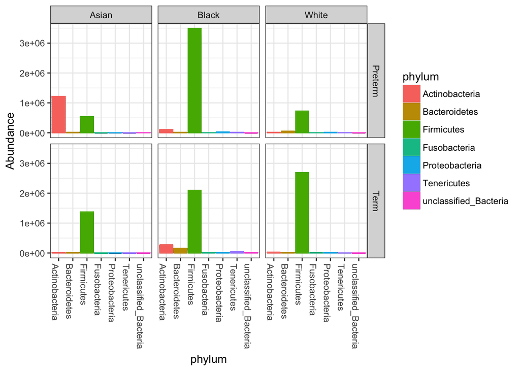

```r
plot_bar(physeq.f, "phylum", fill="phylum", facet_grid = term_vs_preterm_delivery~race) +
  geom_bar(aes(color=phylum, fill=phylum), stat="identity", position = "stack")
```

```r
# Go over the phyloseq tutorials to explore additional features
```

Next, we will plot stacked bars by clustering samples on their bray-curtis dissimilarities.

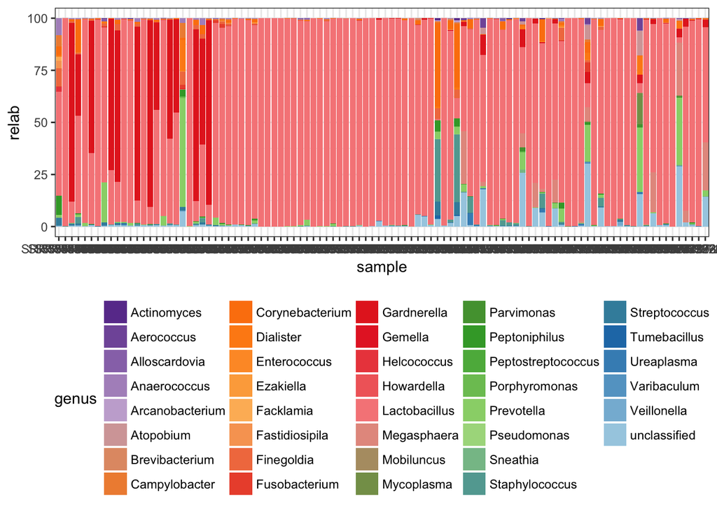

```r
# transform counts to relative abundance
physeq.f.ra <- transform_sample_counts(physeq.f, function(x) x*100/sum(x))

# agglomerate counts at genus-level
physeq.f.ra.genus <- tax_glom(physeq.f.ra, "genus")

# next get the otu_table
propData <- as.data.frame(t(otu_table(physeq.f.ra.genus)))

# get melted dataframe
plotDF <- propData %>%
  rownames_to_column(var="sample") %>%
  melt() %>%
  set_names(c("sample", "taxa", "relab"))
# add taxonomy to plotting DF
taxonomy.2 <- taxonomy %>%
  as.data.frame() %>%
  rownames_to_column(var="taxa")
plotDF <- left_join(plotDF, taxonomy.2, by="taxa") %>%
  select(sample, taxa, relab, genus)
# aggregate all unclassified taxa levels
tot_unc <- plotDF %>%
  group_by(sample) %>%
  filter(grepl("unclassified", genus)) %>%
  summarise(relab=sum(relab)) %>%
  mutate(taxa = "unclassified", genus = "unclassified")

# add the unclassified aggregated rel ab to plotting data frame
plotDF <- plotDF %>%
  filter(!grepl("unclassified", genus)) %>%
  rbind(tot_unc)

# add metadata to plotting DF
metadata.2 <- metadata %>%
  rownames_to_column(var="sample")
plotDF <- left_join(plotDF, metadata.2, by="sample")

# lets plot stacked bars using ggplot2
mycolors <- rev(colorRampPalette(brewer.pal(10, "Paired"))(length(unique(plotDF$genus))))
ggplot(plotDF, aes(sample, relab, fill=genus)) +
  geom_bar(stat="identity", position = "stack") +
  scale_fill_manual(values = mycolors) +
  theme(legend.position = "bottom")
```

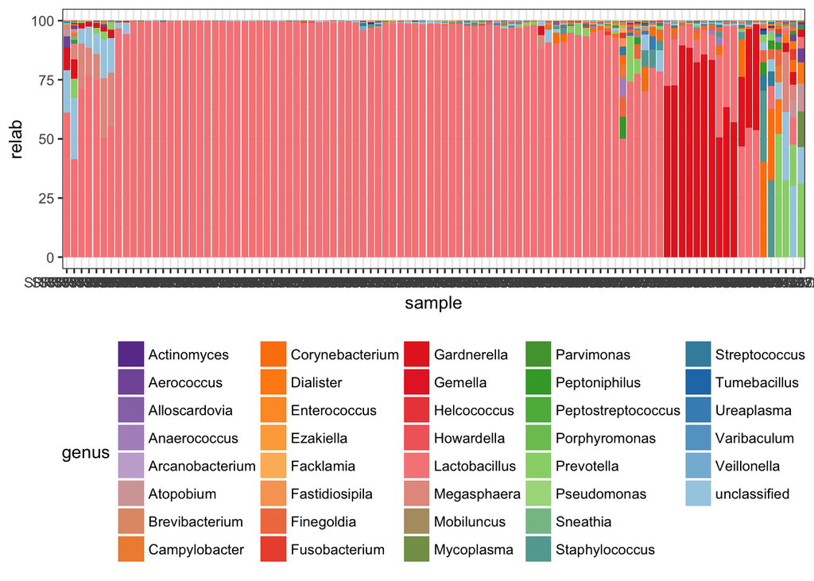

```r
# sort samples on bray-curtis distances
bcdist <- vegdist(propData, method="bray")
hclustBC <- hclust(bcdist, method="ward.D2")
# set sample factor levels
plotDF$sample <- factor(plotDF$sample, levels = hclustBC$labels[c(hclustBC$order)])

# plot again
ggplot(plotDF, aes(sample, relab, fill=genus, group=relab)) +
  geom_bar(stat="identity", position = "stack") +
  scale_fill_manual(values = mycolors) +
  theme(legend.position = "bottom")
```

### Alpha Diversity

Read More: [Phyloseq Alpha diversity](https://joey711.github.io/phyloseq/plot_richness-examples.html)

Alpha diversity refers to community *richness*, i.e. how many different *types* of organisms are present, and *evenness*, i.e. how even/uneven the distribution of species abundance is, in a sample. Alpha-diversity analyses are useful for examining patterns of dominance, rarity and community complexity.

Plot alpha diversity using the `plot_richness()` function

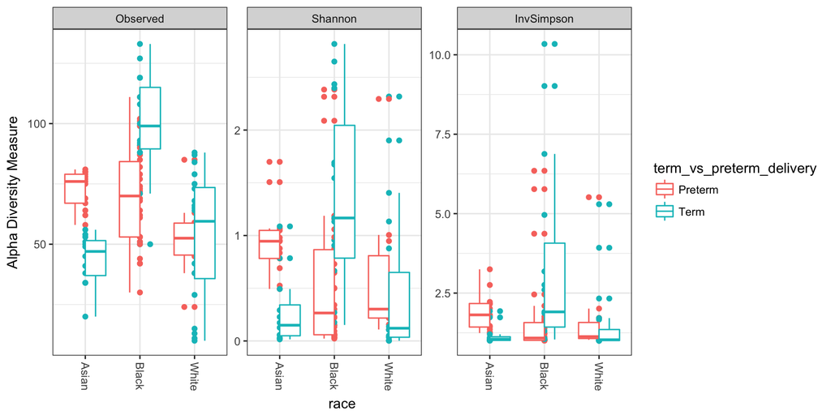

```r
# alpha diversity is measured on count data in phyloseq
plot_richness(physeq.f,
              x = "race",
              color = "term_vs_preterm_delivery",
              measures = c("Observed", "Shannon", "InvSimpson")) +
  geom_boxplot()
```

In this section, we will calculate the same measures of alpha diversity using the *vegan* package, followed by comparing means within groups using *ggpubr* package

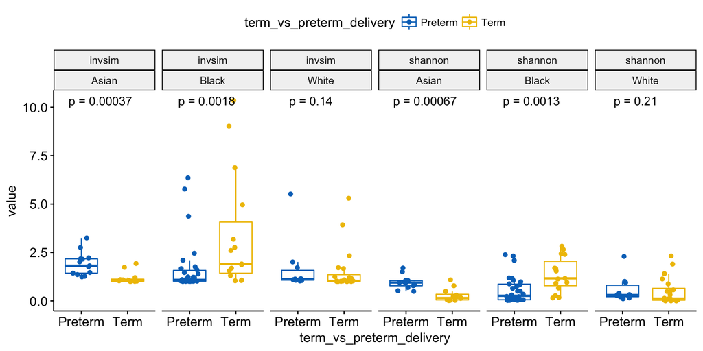

```r
# calculating alpha diversity on proportional data
# R package: vegan

propData <- as.data.frame(t(otu_table(physeq.f.ra)))

# calculate shannon index, manipulate data frame for plotting
adivDF.shannon <- as.data.frame(diversity(propData, index = "shannon")) %>%
  rownames_to_column(var="sample") %>%
  set_names(c("sample", "value")) %>%
  mutate(index = "shannon")

# calculate invsim index, manipulate data frame for plotting
adivDF.invsim <- as.data.frame(diversity(propData, index = "invsim")) %>%
  rownames_to_column(var="sample") %>%
  set_names(c("sample", "value")) %>%
  mutate(index = "invsim")

# create plotting dataframe
adivDF <- rbind(adivDF.shannon, adivDF.invsim) %>%
  left_join(metadata.2, by="sample")

# plot using ggpubr
ggboxplot(adivDF, "term_vs_preterm_delivery", "value",
          color = "term_vs_preterm_delivery", palette = "jco",
          add = "jitter", outlier.shape=NA) +
  facet_grid(~index+race) +
  stat_compare_means(label = "p.format")
```

### Beta Diversity, Ordinations

Read More: [Ordination Plots](https://joey711.github.io/phyloseq/plot_ordination-examples.html)

Beta diversity refers to between sample diversity, summerize how similar/dissimilar two samples are. The taxa abundances in each sample gets compared to every other sample in the dataset, generating a distance matrix, which can be visualized using Principal Coordinate Analysis.

*Bray-Curtis distances*

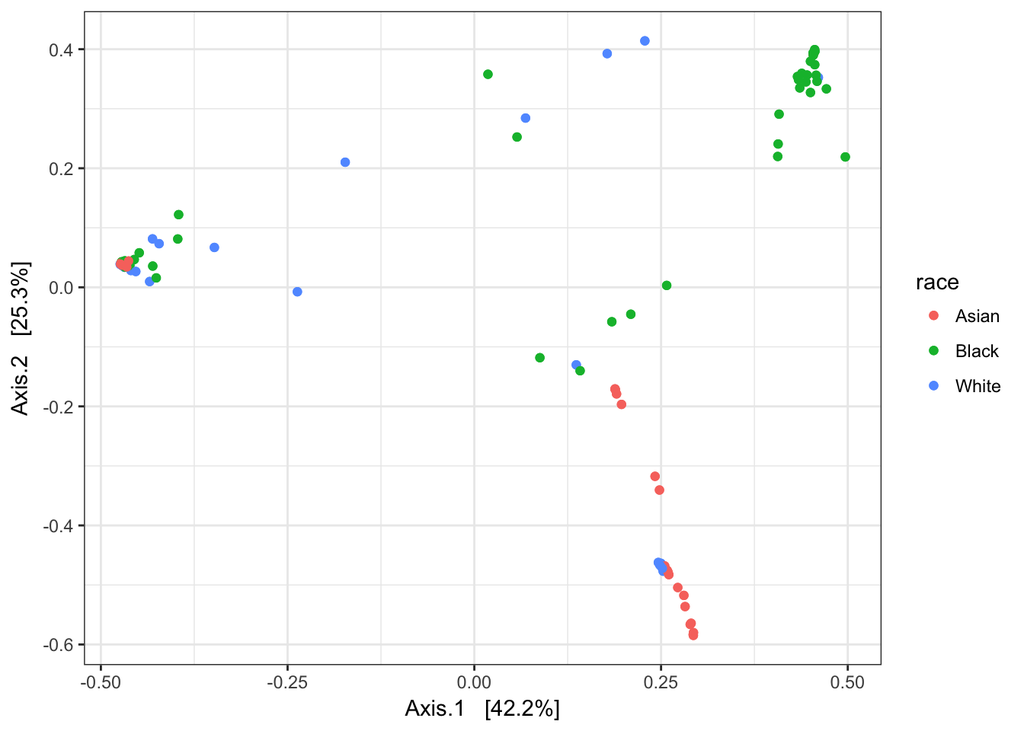

```r
# first calculate bray-curtis distance
physeq.f.distBC <- distance(physeq.f, method="bray")
physeq.f.distBC.ord <- ordinate(physeq.f, method = "PCoA", distance = physeq.f.distBC)

# color by metadata
plot_ordination(physeq.f, physeq.f.distBC.ord, color="race") + geom_point()
```

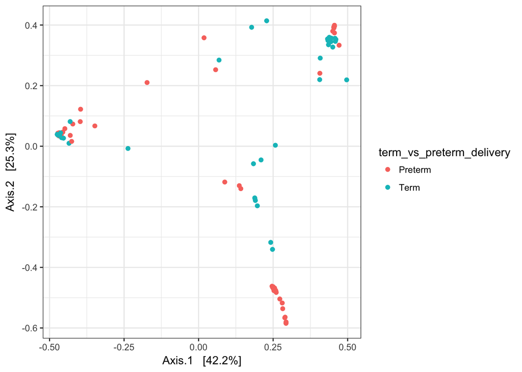

```r
plot_ordination(physeq.f, physeq.f.distBC.ord, color="term_vs_preterm_delivery") + geom_point()
```

*UniFrac distances*

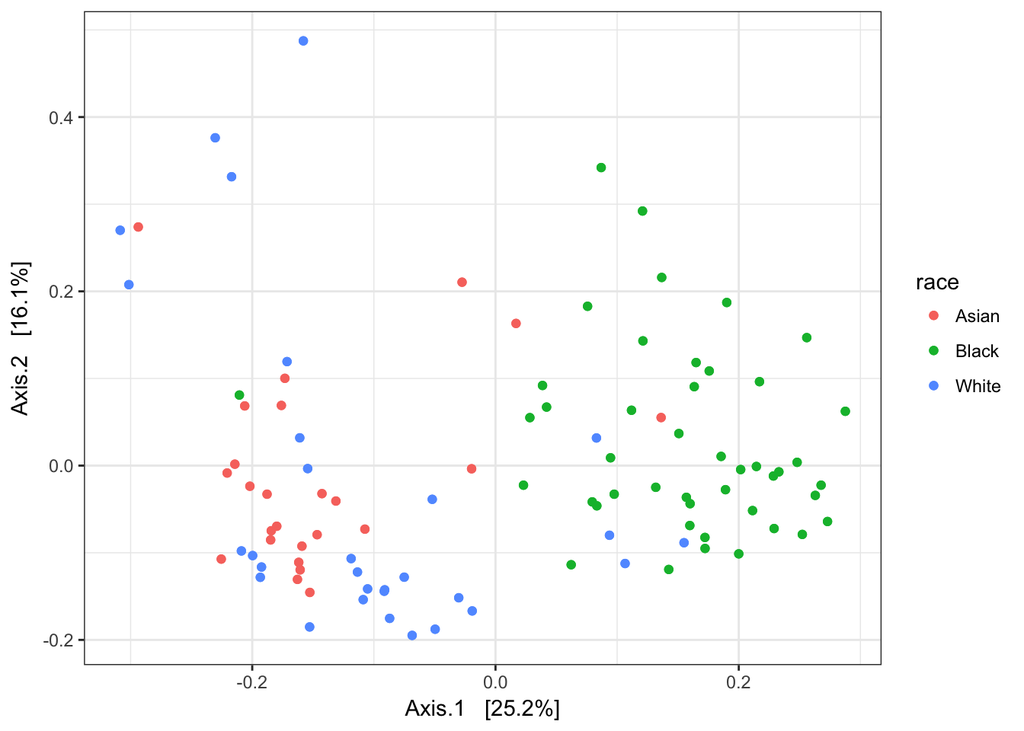

```r
# first calculate unifrac distance
physeq.f.distUF <- distance(physeq.f, method="unifrac")
physeq.f.distUF.ord <- ordinate(physeq.f, method = "PCoA", distance = physeq.f.distUF)

# color by metadata
plot_ordination(physeq.f, physeq.f.distUF.ord, color="race") + geom_point()
```

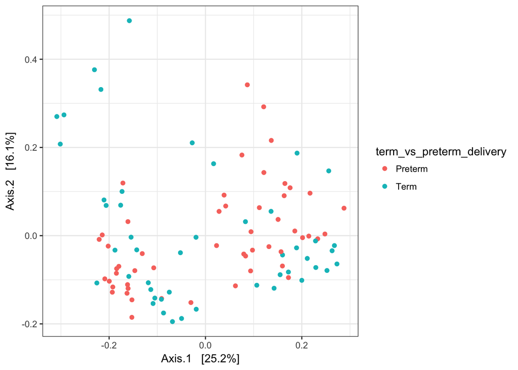

```r
plot_ordination(physeq.f, physeq.f.distUF.ord, color="term_vs_preterm_delivery") + geom_point()
```

### DESeq2

**Which taxa are important?**  
The ordination plots reveal microbiome levels shifts within groups-of-interest. A univariate analysis of individual taxa abudances can be performed using DESeq2, to measure *significant fold changes*.

`phyloseq_to_deseq2()` function provides a convenient function to convert `phyloseq` object to `DESeq2DataSet` class.

```r
library(DESeq2)
# convert to DESeq2's data class
diagdds <- phyloseq_to_deseq2(physeq.f, ~ term_vs_preterm_delivery)
# perform the testing
diagdds <- DESeq(diagdds, test="Wald", fitType="parametric")
```

```
## -- note: fitType='parametric', but the dispersion trend was not well captured by the
##    function: y = a/x + b, and a local regression fit was automatically substituted.
##    specify fitType='local' or 'mean' to avoid this message next time.
```

```
## -- replacing outliers and refitting for 112 genes
## -- DESeq argument 'minReplicatesForReplace' = 7
## -- original counts are preserved in counts(dds)
```

```r
# look at the results
res <- results(diagdds, cooksCutoff = FALSE)
sigtab <- res[which(res$padj < 0.01), ]
sigtab <- cbind(as(sigtab, "data.frame"), as(tax_table(physeq.f)[rownames(sigtab), ], "matrix"))
head(sigtab)
```

```
##            baseMean log2FoldChange     lfcSE       stat       pvalue
## OTU_111   1767.5124     -11.982176 1.5800953  -7.583198 3.371385e-14
## OTU_303   1178.4559     -10.742514 1.5008538  -7.157602 8.210050e-13
## OTU_5   258736.2200      -4.154370 0.9431855  -4.404616 1.059716e-05
## OTU_302    138.3865      -6.686948 1.2958589  -5.160244 2.466285e-07
## OTU_541    196.9992     -15.118544 1.2568358 -12.029053 2.500124e-33
## OTU_91    1354.4135     -14.692651 1.3425713 -10.943665 7.125963e-28
##                 padj   domain                phylum                 class
## OTU_111 4.015014e-13 Bacteria            Firmicutes               Bacilli
## OTU_303 8.273204e-12 Bacteria            Firmicutes               Bacilli
## OTU_5   5.845259e-05 Bacteria            Firmicutes               Bacilli
## OTU_302 1.615417e-06 Bacteria            Firmicutes               Bacilli
## OTU_541 1.091721e-31 Bacteria unclassified_Bacteria unclassified_Bacteria
## OTU_91  2.333753e-26 Bacteria            Firmicutes               Bacilli
##                         order                       family
## OTU_111       Lactobacillales             Lactobacillaceae
## OTU_303       Lactobacillales             Lactobacillaceae
## OTU_5         Lactobacillales             Lactobacillaceae
## OTU_302       Lactobacillales             Lactobacillaceae
## OTU_541 unclassified_Bacteria        unclassified_Bacteria
## OTU_91        Lactobacillales unclassified_Lactobacillales
##                                genus
## OTU_111                Lactobacillus
## OTU_303                Lactobacillus
## OTU_5                  Lactobacillus
## OTU_302                Lactobacillus
## OTU_541        unclassified_Bacteria
## OTU_91  unclassified_Lactobacillales
```

Other popular biomarker discovery tools, utilizing multivariate analysis:  
- [LEfSe](https://bitbucket.org/biobakery/biobakery/wiki/lefse)  
- [Indicator Analysis](https://cran.r-project.org/web/packages/indicspecies/vignettes/indicspeciesTutorial.pdf)